# 19 Quasiquotation

2023-07-20

# 19 Quasiquotation

## 19.1 Introduction

```r
library(rlang)
library(purrr)
```

## 19.2 Motivation

```r
paste("Good", "morning", "Hadley")
```

```
## [1] "Good morning Hadley"
```

```r
paste("Good", "afternoon", "Alice")
```

```
## [1] "Good afternoon Alice"
```

```r
cement <- function(...) {
  args <- ensyms(...)
  paste(purrr::map(args, as_string), collapse = " ")
}

cement(Good, morning, Hadley)
```

```
## [1] "Good morning Hadley"
```

```r
cement(Good, afternoon, Alice)
```

```
## [1] "Good afternoon Alice"
```

```r
name <- "Hadley"
time <- "morning"

paste("Good", time, name)
```

```
## [1] "Good morning Hadley"
```

```r
cement(Good, time, name)
```

```
## [1] "Good time name"
```

```r
cement(Good, !!time, !!name)
```

```
## [1] "Good morning Hadley"
```

```r
paste("Good", time, name)
```

```
## [1] "Good morning Hadley"
```

```r
cement(Good, !!time, !!name)
```

```
## [1] "Good morning Hadley"
```

### 19.2.1 Vocabulary

```r
library(MASS)

# fails
MASS
```

### 19.2.2 Exercises

1.For each function in the following base R code, identify which arguments are quoted and which are evaluated.

```r
library(MASS) # MASS is quoted
MASS

mtcars2 <- subset(mtcars, cyl == 4) # mtcars is evaluated, and cyl is quoted
mtcars
cyl == 4

with(mtcars2, sum(vs)) # mtcars is evaluated and sum(vs) is quoted
mtcars2
sum(vs)

sum(mtcars2$am) #mtcars2$am is evaulated and am is quoted
mtcars2$am
$am

rm(mtcars2) # mtcars2 is quoted
```

```
## Error: <text>:14:1: unexpected '$'
## 13: mtcars2$am
## 14: $
##     ^
```

2. For each function in the following tidyverse code, identify which arguments are quoted and which are evaluated.

```r
library(dplyr) # dplyr is quoted
```

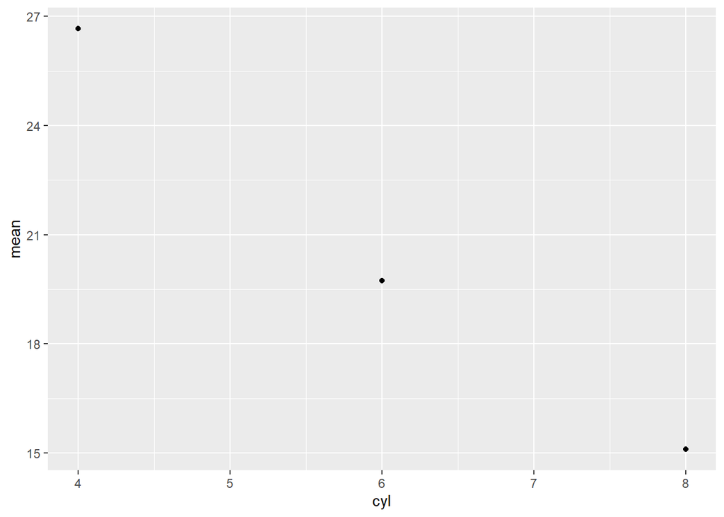

```r
library(ggplot2) #ggplot2 is quoted

by_cyl <- mtcars %>% # mtcars is evaluated
  group_by(cyl) %>% #cyl is quoted
  summarise(mean = mean(mpg)) # mean = mean(mpg) is quoted

ggplot(by_cyl, aes(cyl, mean)) + geom_point() # by_cyl evaluated, aes is evaluated, cyl and mean are quoted
```

## 19.3 Quoting

### 19.3.1 Capturing expressions

```r
expr(x + y)
```

```
## x + y
```

```r
expr(1 / 2 / 3)
```

```
## 1/2/3
```

```r
f1 <- function(x) expr(x)
f1(a + b + c)
```

```
## x
```

```r
f2 <- function(x) enexpr(x)
f2(a + b + c)
```

```
## a + b + c
```

```r
f <- function(...) enexprs(...)
f(x = 1, y = 10 * z)
```

```
## $x
## [1] 1
##
## $y
## 10 * z
```

```r
exprs(x = x ^ 2, y = y ^ 3, z = z ^ 4)
```

```
## $x
## x^2
##
## $y
## y^3
##
## $z
## z^4
```

### 19.3.2 Capturing symbols

```r
f <- function(...) ensyms(...)
f(x)
```

```
## [[1]]
## x
```

```r
f("x")
```

```
## [[1]]
## x
```

### 19.3.3 With base R

```r
quote(x + y)
```

```
## x + y
```

```r
f3 <- function(x) substitute(x)
f3(x + y)
```

```
## x + y
```

```r
alist(x = 1, y = x + 2)
```

```
## $x
## [1] 1
##
## $y
## x + 2
```

```r
f <- function(...) as.list(substitute(...()))
f(x = 1, y = 10 * z)
```

```
## $x
## [1] 1
##
## $y
## 10 * z
```

### 19.3.4 Substitution

```r
f4 <- function(x) substitute(x * 2)
f4(a + b + c)
```

```
## (a + b + c) * 2
```

```r
substitute(x * y * z, list(x = 10, y = quote(a + b)))
```

```
## 10 * (a + b) * z
```

### 19.3.5 Summary

### 19.3.6 Exercises

1. How is `expr()` implemented? Look at its source code.

```r
expr
```

```
## function (expr)
## {
##     enexpr(expr)
## }
## <bytecode: 0x000001a210a676c0>
## <environment: namespace:rlang>
```

It’s a wrapper for `enexpr`

2. Compare and contrast the following two functions. Can you predict the output before running them?

```r
f1 <- function(x, y) {
  exprs(x = x, y = y)
} # captures x = x and y = y
f2 <- function(x, y) {
  enexprs(x = x, y = y)
} # captures the user input en is for users input therefore we'd get x = a + b and y = c + d
f1(a + b, c + d)
```

```
## $x
## x
##
## $y
## y
```

```r
f2(a + b, c + d)
```

```
## $x
## a + b
##
## $y
## c + d
```

3. What happens if you try to use `enexpr()` with an expression (i.e. `enexpr(x + y)` ? What happens if `enexpr()` is passed a missing argument?

```r
enexpr(x + y)
```

```
## Error in `enexpr()`:
## ! `arg` must be a symbol
```

You get an error, the argument has to be a symbol

```r
enexpr(x = )
```

```
## Error in enexpr(x = ): unused argument (alist(x = ))
```

You get an error for an unused argument

4. How are `exprs(a)` and `exprs(a = )` different? Think about both the input and the output.

```r
exprs(a)
```

```
## [[1]]
## a
```

```r
exprs(a = )
```

[output not shown]

First one you get a list with the value “a” in the second you get a list with an object “a” which doesn’t have a value

5. What are other differences between `exprs()` and `alist()`? Read the documentation for the named arguments of `exprs()` to find out.

.named If TRUE, unnamed inputs are automatically named with as_label()

6. The documentation for `substitute()` says:

Substitution takes place by examining each component of the parse tree as follows:

- If it is not a bound symbol in env, it is unchanged.
- If it is a promise object (i.e., a formal argument to a function) the expression slot of the promise replaces the symbol.
- If it is an ordinary variable, its value is substituted, unless env is .GlobalEnv in which case the symbol is left unchanged.

```r
substitute(x + y, list(x = 2)) # y does not change
```

```
## 2 + y
```

```r
substitute(mean(x, ...), list(x = 1, na.rm = T)) # spits back the function with the symbols replaced
```

```
## mean(1, ...)
```

```r
y <- 5
substitute(x + y, .GlobalEnv) # doesn't change y
```

```
## x + y
```

## 19.4 Unquoting

### 19.4.1 Unquoting one argument

```r
x <- expr(-1)
expr(f(!!x, y))
```

```
## f(-1, y)
```

```r
a <- sym("y")
b <- 1
expr(f(!!a, !!b))
```

```
## f(y, 1)
```

```r
mean_rm <- function(var) {
  var <- ensym(var)
  expr(mean(!!var, na.rm = TRUE))
}
expr(!!mean_rm(x) + !!mean_rm(y))
```

```
## mean(x, na.rm = TRUE) + mean(y, na.rm = TRUE)
```

```r
x1 <- expr(x + 1)
x2 <- expr(x + 2)

expr(!!x1 / !!x2)
```

```
## (x + 1)/(x + 2)
```

### 19.4.2 Unquoting a function

```r
f <- expr(foo)
expr((!!f)(x, y))
```

```
## foo(x, y)
```

```r
f <- expr(pkg::foo)
expr((!!f)(x, y))
```

```
## pkg::foo(x, y)
```

```r
f <- expr(pkg::foo)
call2(f, expr(x), expr(y))
```

```
## pkg::foo(x, y)
```

### 19.4.3 Unquoting a missing argument

```r
arg <- missing_arg()
expr(foo(!!arg, !!arg))
```

```
## Error in eval(expr, envir, enclos): argument "arg" is missing, with no default
```

```r
expr(foo(!!maybe_missing(arg), !!maybe_missing(arg)))
```

```
## foo(, )
```

### 19.4.4 Unquoting in special forms

```r
expr(df$!!x)
```

```
## Error: <text>:1:9: unexpected '!'
## 1: expr(df$!
##             ^
```

```r
x <- expr(x)
expr(`$`(df, !!x))
```

```
## df$x
```

### 19.4.5 Unquoting many arguments

```r
xs <- exprs(1, a, -b)
expr(f(!!!xs, y))
```

```
## f(1, a, -b, y)
```

```r
ys <- set_names(xs, c("a", "b", "c"))
expr(f(!!!ys, d = 4))
```

```
## f(a = 1, b = a, c = -b, d = 4)
```

```r
call2("f", !!!xs, expr(y))
```

```
## f(1, a, -b, y)
```

### 19.4.6 The polite fiction of !!

```r
!!TRUE
```

```
## [1] TRUE
```

```r
!!!TRUE
```

```
## [1] FALSE
```

```r
x <- quote(variable)
!!x
```

```
## Error in !x: invalid argument type
```

```r
# BAD
df <- data.frame(x = 1:5)
y <- 100
with(df, x + !!y)
```

```
## [1] 2 3 4 5 6
```

### 19.4.7 Non-standard ASTs

```r
x1 <- expr(class(!!data.frame(x = 10)))
x1
```

```
## class(list(x = 10))
```

```r
eval(x1)
```

```
## [1] "data.frame"
```

```r
expr_print(x1)
```

```
## class(<df[,1]>)
```

```r
lobstr::ast(!!x1)
```

```
## █─class
## └─<inline data.frame>
```

```r
x2 <- expr(f(!!c(1L, 2L, 3L, 4L, 5L)))
x2
```

```
## f(1:5)
```

```r
expr_print(x2)
```

```
## f(<int: 1L, 2L, 3L, 4L, 5L>)
```

```r
lobstr::ast(!!x2)
```

```
## █─f
## └─<inline integer>
```

```r
x3 <- expr(1 + !!expr(2 + 3))
x3
```

```
## 1 + (2 + 3)
```

```r
lobstr::ast(!!x3)
```

```
## █─`+`
## ├─1
## └─█─`+`
##   ├─2
##   └─3
```

### 19.4.8 Exercises

1. Given the following components:, Use quasiquotation to construct the following calls:

```r
xy <- expr(x + y)
xz <- expr(x + z)
yz <- expr(y + z)
abc <- exprs(a, b, c)
```

```r
# (x + y) / (y + z)
expr(!!xy / !!yz)
```

```
## (x + y)/(y + z)
```

```r
#-(x + z) ^ (y + z)
expr(-`^`(!!xz, !!yz))
```

```
## -(x + z)^(y + z)
```

```r
# (x + y) + (y + z) - (x + y)
expr(((!!xy)) + !!yz - !!xy)
```

```
## (x + y) + (y + z) - (x + y)
```

```r
#atan2(x + y, y + z)
expr(atan2(!!xy, !!yz))
```

```
## atan2(x + y, y + z)
```

```r
#sum(x + y, x + y, y + z)
expr(sum(!!xy, !!xy, !!yz))
```

```
## sum(x + y, x + y, y + z)
```

```r
#sum(a, b, c)
expr(sum(!!!abc))
```

```
## sum(a, b, c)
```

```r
#mean(c(a, b, c), na.rm = TRUE)
expr(mean(c(!!!abc), na.rm = TRUE))
```

```
## mean(c(a, b, c), na.rm = TRUE)
```

```r
#foo(a = x + y, b = y + z)
expr(foo(a = !!xy, b = !!yz))
```

```
## foo(a = x + y, b = y + z)
```

2. The following two calls print the same, but are actually different:

```r
(a <- expr(mean(1:10)))
```

```
## mean(1:10)
```

```r
(b <- expr(mean(!!(1:10))))
```

```
## mean(1:10)
```

```r
(c <- expr(mean(!!1:10)))
```

```
## mean(1:10)
```

```r
identical(a, b)
```

```
## [1] FALSE
```

```r
identical(a,c)
```

[output not shown]

```r
mean(1:10)
```

```
## [1] 5.5
```

```r
mean(!!(1:10))
```

```
## [1] 1
```

The first is taking the mean of 1:10, while the second is taking the mean of a vector TRUEs. The second takes 1:10, negates it, were TRUE, now they’re FALSE, then negates that to all TRUE. The presence of the `()` causes this

## 19.5 Non-quoting

```r
xyz <- bquote((x + y + z))
bquote(-.(xyz) / 2)
```

```
## -(x + y + z)/2
```

```r
x <- list(var = 1, y = 2)
var <- "y"

x$var
```

```
## [1] 1
```

```r
x[[var]]
```

```
## [1] 2
```

```r
x <- 1
rm(x)

y <- 2
vars <- c("y", "vars")
rm(list = vars)
```

```r
# Shows help for var
help(var)
```

```
## starting httpd help server ... done
```

```r
var <- "mean"
# Shows help for mean
help(var)

var <- 10
# Shows help for var
help(var)
```

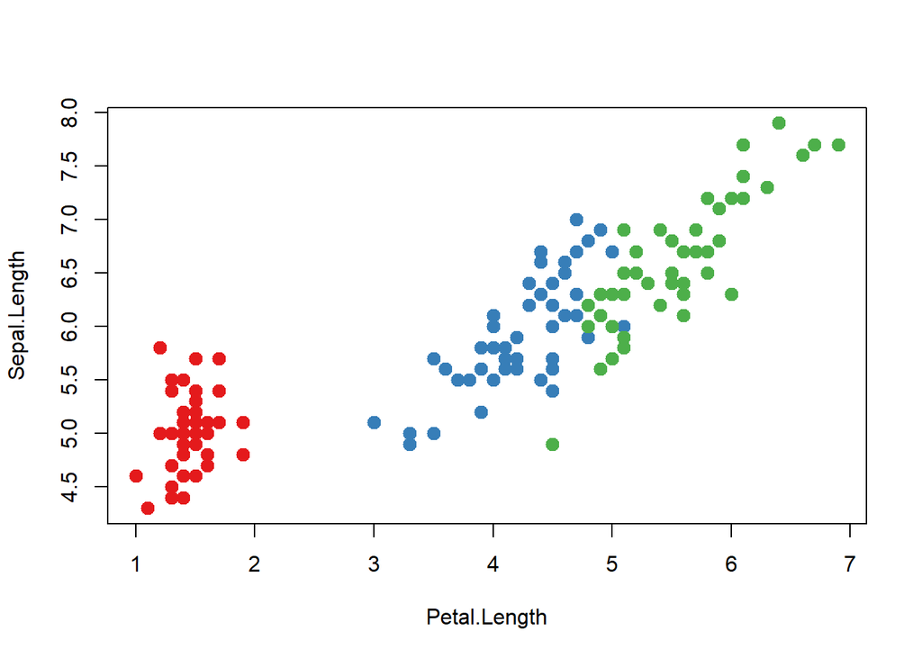

```r
palette(RColorBrewer::brewer.pal(3, "Set1"))
plot(
  Sepal.Length ~ Petal.Length,
  data = iris,
  col = Species,
  pch = 20,
  cex = 2
)
```

## 19.6 … (dot-dot-dot)

```r
dfs <- list(
  a = data.frame(x = 1, y = 2),
  b = data.frame(x = 3, y = 4)
)
```

```r
var <- "x"
val <- c(4, 3, 9)
```

```r
dplyr::bind_rows(!!!dfs)
```

```
##   x y
## 1 1 2
## 2 3 4
```

```r
tibble::tibble(!!var := val)
```

```
## # A tibble: 3 × 1
##       x
##   <dbl>
## 1     4
## 2     3
## 3     9
```

```r
tibble::tibble(!!var = value)
```

```
## Error: <text>:1:22: unexpected '='
## 1: tibble::tibble(!!var =
##                          ^
```

### 19.6.1 Examples

```r
set_attr <- function(.x, ...) {
  attr <- rlang::list2(...)
  attributes(.x) <- attr
  .x
}

attrs <- list(x = 1, y = 2)
attr_name <- "z"

1:10 %>%
  set_attr(w = 0, !!!attrs, !!attr_name := 3) %>%
  str()
```

```
##  int [1:10] 1 2 3 4 5 6 7 8 9 10
##  - attr(*, "w")= num 0
##  - attr(*, "x")= num 1
##  - attr(*, "y")= num 2
##  - attr(*, "z")= num 3
```

### 19.6.2 exec()

```r
# Directly
exec("mean", x = 1:10, na.rm = TRUE, trim = 0.1)
```

```
## [1] 5.5
```

```r
# Indirectly
args <- list(x = 1:10, na.rm = TRUE, trim = 0.1)
exec("mean", !!!args)
```

```
## [1] 5.5
```

```r
# Mixed
params <- list(na.rm = TRUE, trim = 0.1)
exec("mean", x = 1:10, !!!params)
```

```
## [1] 5.5
```

```r
arg_name <- "na.rm"
arg_val <- TRUE
exec("mean", 1:10, !!arg_name := arg_val)
```

```
## [1] 5.5
```

```r
x <- c(runif(10), NA)
funs <- c("mean", "median", "sd")

purrr::map_dbl(funs, exec, x, na.rm = TRUE)
```

```
## [1] 0.4036039 0.4051645 0.2101875
```

### 19.6.3 dots_list()

```r
# Can easily move x to first entry:
tibble::tibble(
  y = 1:5,
  z = 3:-1,
  x = 5:1,
)
```

```
## # A tibble: 5 × 3
##       y     z     x
##   <int> <int> <int>
## 1     1     3     5
## 2     2     2     4
## 3     3     1     3
## 4     4     0     2
## 5     5    -1     1
```

```r
# Need to remove comma from z and add comma to x
data.frame(
  y = 1:5,
  z = 3:-1,
  x = 5:1
)
```

```
##   y  z x
## 1 1  3 5
## 2 2  2 4
## 3 3  1 3
## 4 4  0 2
## 5 5 -1 1
```

```r
str(dots_list(x = 1, x = 2))
```

```
## List of 2
##  $ x: num 1
##  $ x: num 2
```

```r
str(dots_list(x = 1, x = 2, .homonyms = "first"))
```

```
## List of 1
##  $ x: num 1
```

```r
str(dots_list(x = 1, x = 2, .homonyms = "last"))
```

```
## List of 1
##  $ x: num 2
```

```r
str(dots_list(x = 1, x = 2, .homonyms = "error"))
```

```
## Error:
## ! Arguments in `...` must have unique names.
## ✖ Multiple arguments named `x` at positions 1 and 2.
```

### 19.6.4 With base R

```r
do.call("rbind", dfs)
```

```
##   x y
## a 1 2
## b 3 4
```

```r
args <- list(val)
names(args) <- var

do.call("data.frame", args)
```

```
##   x
## 1 4
## 2 3
## 3 9
```

```r
f <- function(...) {
  dots <- list(...)
  if (length(dots) == 1 && is.list(dots[[1]])) {
    dots <- dots[[1]]
  }

  # Do something
  ...
}
```

```r
f <- function(..., .dots) {
  dots <- c(list(...), .dots)
  # Do something
}
```

### 19.6.5 Exercises

1. One way to implement exec() is shown below. Describe how it works. What are the key ideas?

```r
exec <- function(f, ..., .env = caller_env()) {
  args <- list2(...)
  do.call(f, args, envir = .env)
}
```

2. Carefully read the source code for `interaction()`, `expand.grid()`, and `par()`. Compare and contrast the techniques they use for switching between dots and list behaviour.

```r
#interaction
#par
#expand.grid
```

`interaction` first gathers … into an object called args using `list`, checks to make sure it’s not empty. If … is of length 1 and is a list it changes its args and narg arguments. It then processes each item in args.

`par` first gathers … into an object called args using `list`. It checks if args is empty and adds .Pars if it is

`expand.grid` does the same thing and decides what to do based on the length of nargs

3. Explain the problem with this definition of `set_attr()`

```r
set_attr <- function(x, ...) {
  attr <- rlang::list2(...)
  attributes(x) <- attr
  x
}
set_attr(1:10, x = 10)
```

```
## Error in attributes(x) <- attr: attributes must be named
```

```r
set_attr <- function(.x, ...) {
  attr <- rlang::list2(...)
  attributes(.x) <- attr
  .x
}
set_attr(1:10, x = 10)
```

```
##  [1]  1  2  3  4  5  6  7  8  9 10
## attr(,"x")
## [1] 10
```

The use of `x` instead of `.x` leads to name conflict issues

## 19.7 Case studies

### 19.7.1 lobstr::ast()

```r
z <- expr(foo(x, y))
lobstr::ast(z)
```

```
## z
```

```r
lobstr::ast(!!z)
```

```
## █─foo
## ├─x
## └─y
```

### 19.7.2 Map-reduce to generate code

```r
intercept <- 10
coefs <- c(x1 = 5, x2 = -4)
```

```r
coef_sym <- syms(names(coefs))
coef_sym
```

```
## [[1]]
## x1
##
## [[2]]
## x2
```

```r
summands <- map2(coef_sym, coefs, ~ expr((!!.x * !!.y)))
summands
```

```
## [[1]]
## (x1 * 5)
##
## [[2]]
## (x2 * -4)
```

```r
summands <- c(intercept, summands)
summands
```

```
## [[1]]
## [1] 10
##
## [[2]]
## (x1 * 5)
##
## [[3]]
## (x2 * -4)
```

```r
eq <- reduce(summands, ~ expr(!!.x + !!.y))
eq
```

```
## 10 + (x1 * 5) + (x2 * -4)
```

```r
var <- expr(y)
coef_sym <- map(seq_along(coefs), ~ expr((!!var)[[!!.x]]))
coef_sym
```

```
## [[1]]
## y[[1L]]
##
## [[2]]
## y[[2L]]
```

```r
linear <- function(var, val) {
  var <- ensym(var)
  coef_name <- map(seq_along(val[-1]), ~ expr((!!var)[[!!.x]]))

  summands <- map2(val[-1], coef_name, ~ expr((!!.x * !!.y)))
  summands <- c(val[[1]], summands)

  reduce(summands, ~ expr(!!.x + !!.y))
}

linear(x, c(10, 5, -4))
```

```
## 10 + (5 * x[[1L]]) + (-4 * x[[2L]])
```

### 19.7.3 Slicing an array

```r
indices <- rep(list(missing_arg()), 3)
expr(x[!!!indices])
```

```
## x[, , ]
```

```r
indices[[2]] <- 1
expr(x[!!!indices])
```

```
## x[, 1, ]
```

```r
slice <- function(x, along, index) {
  stopifnot(length(along) == 1)
  stopifnot(length(index) == 1)

  nd <- length(dim(x))
  indices <- rep(list(missing_arg()), nd)
  indices[[along]] <- index

  expr(x[!!!indices])
}

x <- array(sample(30), c(5, 2, 3))

slice(x, 1, 3)
```

```
## x[3, , ]
```

```r
slice(x, 2, 2)
```

```
## x[, 2, ]
```

```r
slice(x, 3, 1)
```

```
## x[, , 1]
```

### 19.7.4 Creating functions

```r
new_function(
  exprs(x = , y = ),
  expr({x + y})
)
```

```
## function (x, y)
## {
##     x + y
## }
```

```r
power <- function(exponent) {
  new_function(
    exprs(x = ),
    expr({
      x ^ !!exponent
    }),
    caller_env()
  )
}
power(0.5)
```

```
## function (x)
## {
##     x^0.5
## }
```

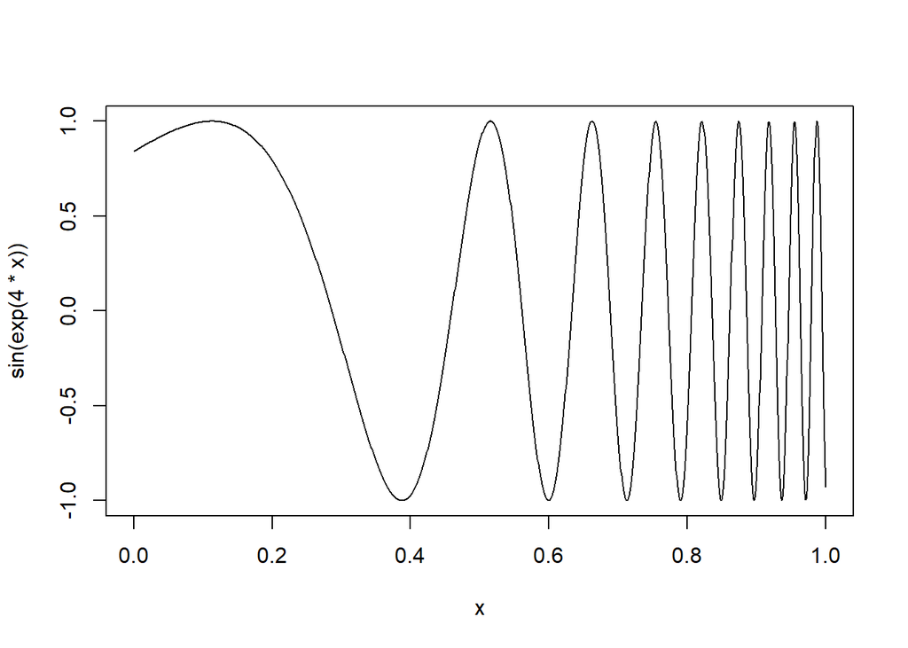

```r
curve(sin(exp(4 * x)), n = 1000)
```

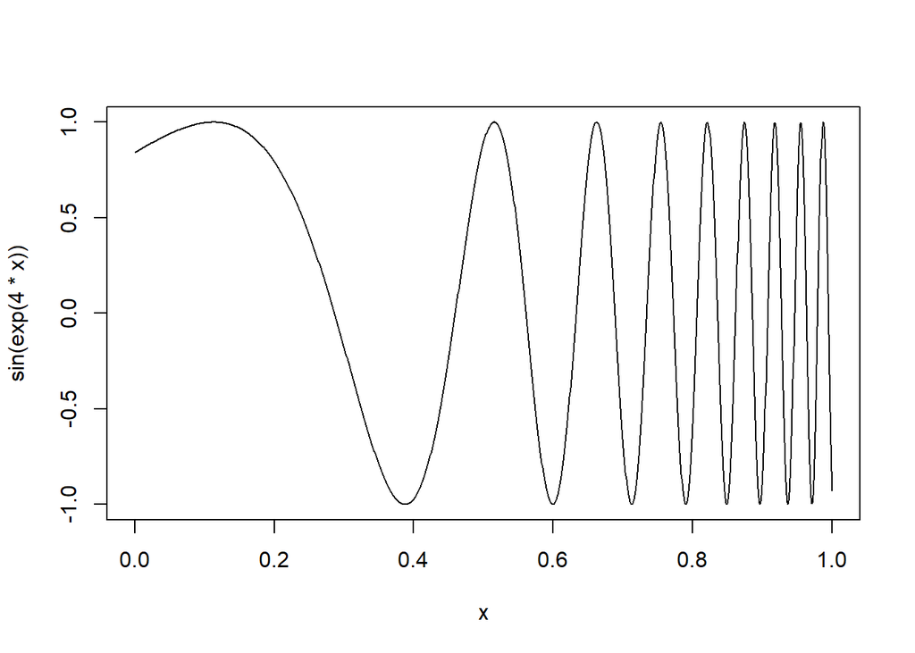

```r
curve2 <- function(expr, xlim = c(0, 1), n = 100) {
  expr <- enexpr(expr)
  f <- new_function(exprs(x = ), expr)

  x <- seq(xlim[1], xlim[2], length = n)
  y <- f(x)

  plot(x, y, type = "l", ylab = expr_text(expr))
}
curve2(sin(exp(4 * x)), n = 1000)
```

### 19.7.5 Exercises

1. In the linear-model example, we could replace the `expr()` in `reduce(summands, ~ expr(!!.x + !!.y))` with `call2()`: `reduce(summands, call2, "+")`. Compare and contrast the two approaches. Which do you think is easier to read?

```r
# expr version
linear <- function(var, val) {
  var <- ensym(var)
  coef_name <- map(seq_along(val[-1]), ~ expr((!!var)[[!!.x]]))

  summands <- map2(val[-1], coef_name, ~ expr((!!.x * !!.y)))
  summands <- c(val[[1]], summands)

  reduce(summands, ~ expr(!!.x + !!.y))
}

linear(x, c(10, 5, -4))
```

```
## 10 + (5 * x[[1L]]) + (-4 * x[[2L]])
```

```r
# call2 version
linear <- function(var, val) {
  var <- ensym(var)
  coef_name <- map(seq_along(val[-1]), ~ expr((!!var)[[!!.x]]))

  summands <- map2(val[-1], coef_name, ~ expr((!!.x * !!.y)))
  summands <- c(val[[1]], summands)

  reduce(summands, call2, .fn = "+")
}

linear(x, c(10, 5, -4))
```

```
## 10 + (5 * x[[1L]]) + (-4 * x[[2L]])
```

2. Re-implement the Box-Cox transform defined below using unquoting and `new_function()`:

```r
bc <- function(lambda) {
  new_function(
    exprs(x = ),
    if (lambda == 0) {
      expr({log(x)})}
    else {
      expr({(x ^ lambda - 1) / lambda})
    },
    caller_env()
  )
}

bc(lambda = 0)
```

```
## function (x)
## {
##     log(x)
## }
```

```r
bc(lambda = 5)
```

```
## function (x)
## {
##     (x^lambda - 1)/lambda
## }
```

3. Re-implement the simple `compose()` defined below using quasiquotation and `new_function()`:

```r
compose <- function(f, g) {
  f <- enexpr(f)
  g <- enexpr(g)
  new_function(
    exprs(... =),
    expr((!!f)((!!g)(...))),
    caller_env()
  )
}

compose(abs, sum)
```

```
## function (...)
## abs(sum(...))
```

```r
wtf <- compose(abs, sum)
wtf(c(1,3,5,6))
```

```
## [1] 15
```

```r
wtf(c(1,3,5,6,-20))
```

```
## [1] 5
```

## 19.8 History